**M2 Project Report**

**Probability Theory and Introductory Statistics**

ALY 6010 - 71579

**Maheswar Raju Narasaiah**

Prof: Dr. Dee Chiluiza

Date:25 November, 2022

**1. INTRODUCTION**

Most professionals shape their behavior through an iterative learning process that includes mental rehearsal, action, and feedback. For those starting a new career or occupation, this process entails attempting to meet certain standards, observing the results, and making the necessary adjustments. These observations may result in increased effort (“I need to improve”), establishing a routine (“I’m doing okay”), or quitting (“I don’t fit here”) (Hader, 2004). These observations may be supported by feedback in a variety of forms, including measuring performance and mentoring by managers, self-comparisons with colleagues, and formal performance evaluations and rewards.

**Benefits of a Compensation Survey**

A compensation survey can reveal how your salary levels and other employment benefits stack up against your industry, competitors, and region. This data can assist you in making better choices about the mix of pay and benefits you offer to attract and retain top personnel. A survey can also detail how employees are compensated, such as:

- The mix of base and variable compensation (rewards, bonus payments, commissions, profit sharing)
- The mix of base and variable compensation (incentives, bonuses, commissions, profit sharing)
- Bonus pool funding
- Vesting schedules and eligibility for equity awards

A survey can also help you evaluate policies like car insurance, maternity and paternity leave, shift premiums, and student loan assistance. How do they compare to what your competitors and industry have to offer? Do they live up to the expectations of prospective employees? Are some benefits that you do not provide becoming the norm?

**What Is a Confidence Interval And Their Application**

In statistics, a confidence interval denotes the likelihood that a population parameter will fall between a set of values for a certain proportion of the time. Analysts frequently employ confidence intervals that contain 95% or 99% of the expected observations. Thus, if a point estimate of 10.00 is generated from a statistical model with a 95% confidence interval of 9.50 - 10.50, there is a 95% chance that the true value falls within that range (Bluman, 2014).

A confidence interval is a set of values bounded above and below the mean of a statistic that are likely to contain an unknown population parameter. The percentage of probability, or certainty, that the confidence interval will contain the true population parameter when a random sample is drawn many times is referred to as the confidence level. Alternatively, “we are 99% certain (confidence level) that most of these samples (confidence intervals) contain the true population parameter,” as the phrase goes.

**Application of Confidence Interval in Project Management**

Suppose a project manager wishes to estimate the average defects, the development team is introducing in software in a month after some development of a feature. He wants to reduce that as customer are concerned. He could select a random sample of past 7 days and find the average defects, team has introduced in this period, say, 24 Defects per week. From the sample mean, the project manager could infer that the average defects for the development in a month is 90 -98 Defects with 95% Confidence.

After the analysis, he will present his finding with his team members to find the root cause of it and make improvement plan to bring down the defect leakage to customer production. He might ask for improving our testing methods to improve satistication of customer.

**2. ANALYSIS**

In this section, we will perform analysis on various types of variables to gain insight and address our problems

```r
#"Library Used for Analysis of Car Sales
library(magrittr)
library(knitr)
library(plotrix)
library(plyr)
library(dplyr)
library(readxl)
library(gridExtra)
library(CGPfunctions)
library(RColorBrewer)
library(lattice)
library(ggplot2)
library(DT)
library(kableExtra)



# Datasets used in Project"

## Salary data

Salary <- read_excel("~/Desktop/Intro To Analytics - ALY 6000/ALY 6010 - Project/Data Sets/M2Data-1.xlsx",
    sheet = "salary_survey")

## Pets Data
Pets <- read_excel("~/Desktop/Intro To Analytics - ALY 6000/ALY 6010 - Project/Data Sets/M2Data-1.xlsx",
    sheet = "pets")

#Salary List
SalaryList <- read_excel("~/Desktop/Intro To Analytics - ALY 6000/ALY 6010 - Project/Data Sets/M2Data-1.xlsx",
    sheet = "salary_list")

#Pets List
Pets_List <- read_excel("~/Desktop/Intro To Analytics - ALY 6000/ALY 6010 - Project/Data Sets/M2Data-1.xlsx",
    sheet = "pets_list")
```

**2.1. ANALYSIS OF SALARY DATA**

*About the Data Set*

In this section, I have examined salary data from 20 stores, which includes details of store name, their compensation package.

We have masked the store name as we want to keep this information confidential.

**2.1.1. Confidence Intervals of Salary Data When Whole Data Was Taken As One**

```r
#Removing NA Values from each column using na.omit() function
Store1 = na.omit(Salary$Store1)
Store2 = na.omit(Salary$Store2)
Store3 = na.omit(Salary$Store3)
Store4 = na.omit(Salary$Store4)
Store5 = na.omit(Salary$Store5)
Store6 = na.omit(Salary$Store6)
Store7 = na.omit(Salary$Store7)
Store8 = na.omit(Salary$Store8)
Store9 = na.omit(Salary$Store9)
Store10 = na.omit(Salary$Store10)
Store11 = na.omit(Salary$Store11)
Store12 = na.omit(Salary$Store12)
Store13 = na.omit(Salary$Store13)
Store14 = na.omit(Salary$Store14)
Store15 = na.omit(Salary$Store15)
Store16 = na.omit(Salary$Store16)
Store17 = na.omit(Salary$Store17)
Store18 = na.omit(Salary$Store18)
Store19 = na.omit(Salary$Store19)
Store20 = na.omit(Salary$Store20)

#Creating for basic statistics for task 1.1
meanSalary = (sum(Store1)+sum(Store2)+sum(Store3)+sum(Store4) +sum(Store5) +sum(Store6)+ sum(Store7) +sum(Store8)+ sum(Store9)
+sum(Store10) +sum(Store11) +sum(Store12) +sum(Store13) +sum(Store14)
+sum(Store15)+ sum(Store16) +sum(Store17) +sum(Store18) +sum(Store19) +sum(Store20))/247


sdSalary = sd(SalaryList$Store)

n = 247


#Creating Object for 90% Confidence Interval
CL90= 0.90

#Calculating Alpha Value
alp90= (1-CL90)

# Calculating Z value for Margin of Error
Z90L= qnorm(alp90/2)

#Calculating Margin of Error
MarErr90 = Z90L*(sdSalary/ sqrt(n))

#Creating Objects for Confidence Interval: Upper and Lower Limit
CLL90= meanSalary + MarErr90
CLU90 = meanSalary - MarErr90

#Calculation of C.I. Width for 90
wd90 = CLU90 - CLL90

#Vector Creation for 90% C.I.
vectorCI90 = c(Z90L, MarErr90, CLU90, CLL90, wd90 )



#Creating Object for 92% Confidence Interval
CL92= 0.92

#Calculating Alpha Value
alp92= (1-CL92)

# Calculating Z value for Margin of Error
Z92L= qnorm(alp92/2)

#Calculating Margin of Error
MarErr92 = Z92L*(sdSalary/ sqrt(n))

#Creating Objects for Confidence Interval: Upper and Lower Limit
CLL92= meanSalary + MarErr92
CLU92 = meanSalary - MarErr92

#Calculation of C.I. Width for 92
wd92 = CLU92 - CLL92


#Vector Creation for 92% C.I.
vectorCI92 = c(Z92L, MarErr92, CLU92, CLL92, wd92 )

#Creating Object for 96% Confidence Interval
CL96= 0.96

#Calculating Alpha Value
alp96= (1-CL96)

# Calculating Z value for Margin of Error
Z96L= qnorm(alp96/2)

#Calculating Margin of Error
MarErr96 = Z96L*(sdSalary/ sqrt(n))

#Creating Objects for Confidence Interval: Upper and Lower Limit
CLL96= meanSalary + MarErr96
CLU96 = meanSalary - MarErr96

#Calculation of C.I. Width for 96
wd96 = CLU96 - CLL96

#Vector Creation for 96% C.I.
vectorCI96 = c(Z96L, MarErr96, CLU96, CLL96, wd96 )

#Matrix Creation for compiling all the Confidence Interval Vectors
Salary_Table = matrix(c(vectorCI90,vectorCI92, vectorCI96 ), nrow = 3, byrow = TRUE)


##Rounding Digits in Matrix
Salary_Table_Rounded = round(Salary_Table, digits = 3)

##Naming Columns and Row Names in Table
colnames (Salary_Table_Rounded) = c("Z Value",  "Marg of Error", "Upper C.L.","Lower C.L.", "Width of C.I.")

rownames (Salary_Table_Rounded) = c("Confidence Interval 90%","Confidence Interval 92%", "Confidence Interval 96%")

#Table Creation of of Matrix Using Knitr Package
Salary_Table_Rounded %>%
  knitr::kable(caption = "Table 1: Z Values, Margin of Error, Upper Confidence limit, Lower Confidence Limit and Width of C.I. of Salaries with Different Confidence Intervals") %>%
  kable_styling(bootstrap_options = c("striped","hover"))
```

Table 1: Z Values, Margin of Error, Upper Confidence limit, Lower Confidence Limit and Width of C.I. of Salaries with Different Confidence Intervals

|  | Z Value | Marg of Error | Upper C.L. | Lower C.L. | Width of C.I. |
| --- | --- | --- | --- | --- | --- |
| Confidence Interval 90% | -1.645 | -0.340 | 12.151 | 11.471 | 0.680 |
| Confidence Interval 92% | -1.751 | -0.362 | 12.173 | 11.449 | 0.724 |
| Confidence Interval 96% | -2.054 | -0.424 | 12.235 | 11.386 | 0.849 |

**2.1.2. Confidence Intervals of Salary Data Where Each Store Was Taken As One Individual Data Set**

```r
#Creating for basic statistics for task 1.2
meanSalary = (mean(Store1)+mean(Store2)+mean(Store3)+mean(Store4) +mean(Store5) +mean(Store6)+ mean(Store7) +mean(Store8)+ mean(Store9)
+mean(Store10) +mean(Store11) +mean(Store12) +mean(Store13) +mean(Store14)
+mean(Store15)+ mean(Store16) +mean(Store17) +mean(Store18) +mean(Store19) +mean(Store20))/20


sdSalary = (sd(Store1)+sd(Store2)+sd(Store3)+sd(Store4) +sd(Store5) +sd(Store6)+ sd(Store7) +sd(Store8)+ sd(Store9)
+sd(Store10) +sd(Store11) +sd(Store12) +sd(Store13) +sd(Store14)
+sd(Store15)+ sd(Store16) +sd(Store17) +sd(Store18) +sd(Store19) +sd(Store20))/20

#Sample Size
n = 20

#Degree of Freedom
df = n-1


#Calculating Confidence for 90 %
CL90= 0.90

#Calculating p Value
p90= (1+CL90)/2

# Calculating t value for Margin of Error using qt()
T90L= qt(p90, df)

#Calculating Margin of Error
MarErr90 = T90L*(sdSalary/ sqrt(n))

#Creating Objects for Confidence Interval: Upper and Lower Limit
CLL90= meanSalary - MarErr90
CLU90 = meanSalary + MarErr90

#Calculation of C.I. Width for 90%
wd90 = CLU90 - CLL90

#Vector Creation for 90% C.I.
vectorCI90 = c(T90L, MarErr90, CLU90, CLL90, wd90 )


#Calculating Confidence for 92 %
CL92= 0.92

#Calculating p Value
p92= (1+CL92)/2

# Calculating t value for Margin of Error using qt()
T92L= qt(p92, df)

#Calculating Margin of Error
MarErr92 = T92L*(sdSalary/ sqrt(n))

#Creating Objects for Confidence Interval: Upper and Lower Limit
CLL92= meanSalary - MarErr92
CLU92 = meanSalary + MarErr92

#Calculation of C.I. Width for 92%
wd92 = CLU92 - CLL92

#Vector Creation for 92% C.I.
vectorCI92 = c(T92L, MarErr92, CLU92, CLL92, wd92 )


#Calculating Confidence for 96 %
CL96= 0.96

#Calculating p Value
p96= (1+CL96)/2

# Calculating t value for Margin of Error using qt()
T96L= qt(p96, df)

#Calculating Margin of Error
MarErr96 = T96L*(sdSalary/ sqrt(n))

#Creating Objects for Confidence Interval: Upper and Lower Limit
CLL96= meanSalary - MarErr96
CLU96 = meanSalary + MarErr96

#Calculation of C.I. Width for 96%
wd96 = CLU96 - CLL96

#Vector Creation for 96% C.I.
vectorCI96 = c(T96L, MarErr96, CLU96, CLL96, wd96 )


#Matrix Creation for compiling all the Confidence Interval Vectors
Salary_Table = matrix(c(vectorCI90,vectorCI92, vectorCI96 ), nrow = 3, byrow = TRUE)


##Rounding Digits in Matrix
Salary_Table_Rounded2 = round(Salary_Table, digits = 3)

##Naming Columns and Row Names in Table
colnames (Salary_Table_Rounded2) = c("T Value",  "Marg of Error", "Upper C.L.","Lower C.L.", "Width of C.I.")

rownames (Salary_Table_Rounded2) = c("Confidence Interval 90%","Confidence Interval 92%", "Confidence Interval 96%")

#Table Creation of of Matrix Using Knitr Package
Salary_Table_Rounded2 %>%
  knitr::kable(caption = "Table 2: T Values, Margin of Error, Upper Confidence limit, Lower Confidence Limit and Width of C.I. of Salaries with Different Confidence Intervals") %>%
  kable_styling(bootstrap_options = c("striped","hover"))
```

Table 2: T Values, Margin of Error, Upper Confidence limit, Lower Confidence Limit and Width of C.I. of Salaries with Different Confidence Intervals

|  | T Value | Marg of Error | Upper C.L. | Lower C.L. | Width of C.I. |
| --- | --- | --- | --- | --- | --- |
| Confidence Interval 90% | 1.729 | 0.468 | 12.298 | 11.362 | 0.936 |
| Confidence Interval 92% | 1.850 | 0.500 | 12.331 | 11.330 | 1.001 |
| Confidence Interval 96% | 2.205 | 0.597 | 12.427 | 11.234 | 1.193 |

**2.1.4. Density Plot**

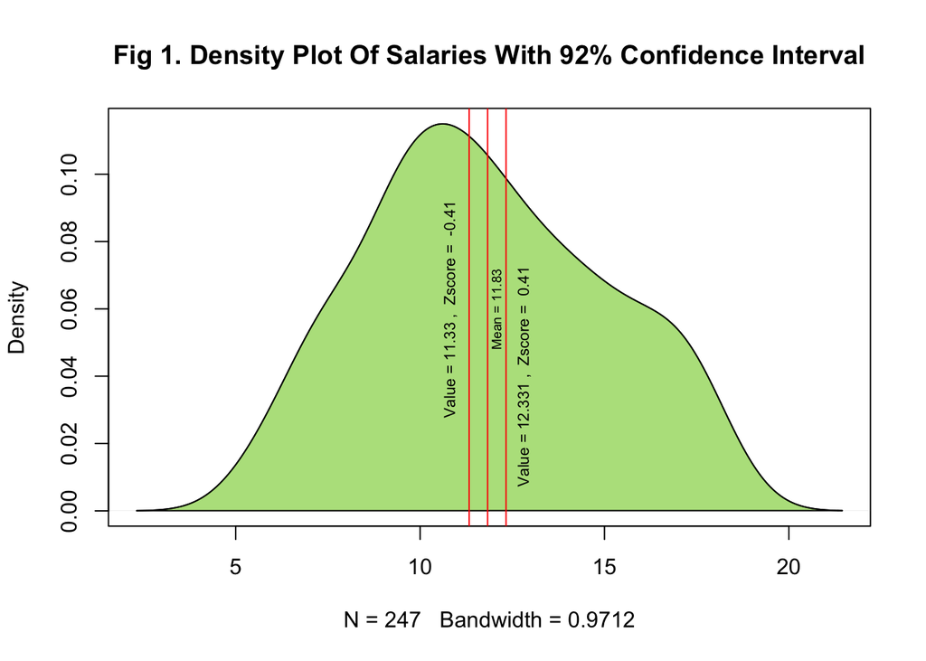

```r
#Plotting the Density Plot

densityStore = density(SalaryList$Store)
plot(densityStore, adjust = 2,main = "Fig 1. Density Plot Of Salaries With 92% Confidence Interval")

# Fill area
polygon(densityStore, col = rgb(0.5, 0.8, 0.157, alpha = 0.6))

#Plotting the Confidence Interval: Upper and Lower Limit on density plot
abline(v= CLL92, col = "Red")
abline(v= CLU92, col = "Red")
abline(v= meanSalary, col = "Red")

#Getting the Z Score for Confidence Upper and Lower Limit
ZscoreL = (CLL92 - meanSalary)/sdSalary
ZscoreU = (CLU92 - meanSalary)/sdSalary

#Adding text for vertical lines"
text(x=CLL92 - 0.5, y=0.06,
     paste("Value =",round(CLL92,2),",  Zscore = ",round(ZscoreL,2)),
     srt=90, cex=0.7)

#Adding text for vertical lines"
text(x=CLU92 + 0.5, y=0.04,
     paste("Value =",round(CLU92,3),",  Zscore = ",round(ZscoreU,2)),
     srt=90, cex=0.7)


#Adding text for vertical lines"
text(x=meanSalary + 0.25, y=0.06,
     paste("Mean =",round(meanSalary,3)),
     srt=90, cex=0.6)
```

**2.1.5. Box Plot with Data Lables for All The Individual Stores**

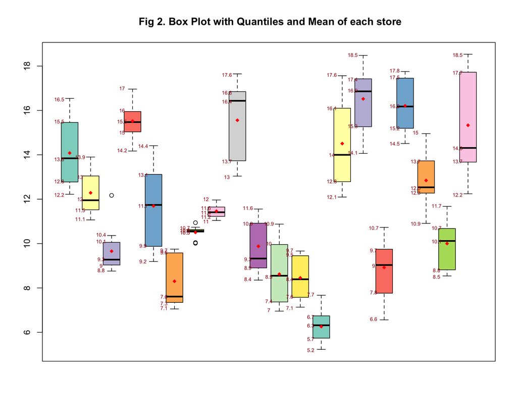

```r
box1 = boxplot.stats(Store1)$stats
box2 = boxplot.stats(Store2)$stats
box3 = boxplot.stats(Store3)$stats
box4 = boxplot.stats(Store4)$stats
box5 = boxplot.stats(Store5)$stats
box6 = boxplot.stats(Store6)$stats
box7 = boxplot.stats(Store7)$stats
box8 = boxplot.stats(Store8)$stats
box9 = boxplot.stats(Store9)$stats
box10 = boxplot.stats(Store10)$stats
box11 = boxplot.stats(Store11)$stats
box12 = boxplot.stats(Store12)$stats
box13 = boxplot.stats(Store13)$stats
box14 = boxplot.stats(Store14)$stats
box15 = boxplot.stats(Store15)$stats
box16 = boxplot.stats(Store16)$stats
box17 = boxplot.stats(Store17)$stats
box18 = boxplot.stats(Store18)$stats
box19 = boxplot.stats(Store19)$stats
box20 = boxplot.stats(Store20)$stats

store_stats = matrix(c(box1, box2, box3, box4, box5, box6, box7, box8, box9, box10, box11, box12, box13, box14, box15, box16, box17, box18, box19, box20), nrow = 20, byrow = TRUE)

##Rounding Digits in Matrix
store_stats_Rounded = round(store_stats, digits = 1)

boxplot(Salary, xaxt = "n", col = brewer.pal(12, "Set3"), main = " Fig 2. Box Plot with Quantiles and Mean of each store")

text(y = store_stats_Rounded[1,],
     labels = store_stats_Rounded[1,],
     x=0.5,
     cex = 0.6,
     col = "#A11515")

text(y = store_stats_Rounded[2,],
     labels = store_stats_Rounded[2,],
     x=1.5,
     cex = 0.6,
     col = "#A11515")

text(y = store_stats_Rounded[3,],
     labels = store_stats_Rounded[3,],
     x=2.5,
     cex = 0.6,
     col = "#A11515")
text(y = store_stats_Rounded[4,],
     labels = store_stats_Rounded[4,],
     x=3.5,
     cex = 0.6,
     col = "#A11515")
text(y = store_stats_Rounded[5,],
     labels = store_stats_Rounded[5,],
     x=4.5,
     cex = 0.6,
     col = "#A11515")
text(y = store_stats_Rounded[6,],
     labels = store_stats_Rounded[6,],
     x=5.5,
     cex = 0.6,
     col = "#A11515")
text(y = store_stats_Rounded[7,],
     labels = store_stats_Rounded[7,],
     x=6.5,
     cex = 0.6,
     col = "#A11515")
text(y = store_stats_Rounded[8,],
     labels = store_stats_Rounded[8,],
     x=7.5,
     cex = 0.6,
     col = "#A11515")
text(y = store_stats_Rounded[9,],
     labels = store_stats_Rounded[9,],
     x=8.5,
     cex = 0.6,
     col = "#A11515")
text(y = store_stats_Rounded[10,],
     labels = store_stats_Rounded[10,],
     x=9.5,
     cex = 0.6,
     col = "#A11515")
text(y = store_stats_Rounded[11,],
     labels = store_stats_Rounded[11,],
     x=10.5,
     cex = 0.6,
     col = "#A11515")
text(y = store_stats_Rounded[12,],
     labels = store_stats_Rounded[12,],
     x=11.5,
     cex = 0.6,
     col = "#A11515")
text(y = store_stats_Rounded[13,],
     labels = store_stats_Rounded[13,],
     x=12.5,
     cex = 0.6,
     col = "#A11515")
text(y = store_stats_Rounded[14,],
     labels = store_stats_Rounded[14,],
     x=13.5,
     cex = 0.6,
     col = "#A11515")
text(y = store_stats_Rounded[15,],
     labels = store_stats_Rounded[15,],
     x=14.5,
     cex = 0.6,
     col = "#A11515")
text(y = store_stats_Rounded[16,],
     labels = store_stats_Rounded[16,],
     x=15.5,
     cex = 0.6,
     col = "#A11515")
text(y = store_stats_Rounded[17,],
     labels = store_stats_Rounded[17,],
     x=16.5,
     cex = 0.6,
     col = "#A11515")
text(y = store_stats_Rounded[18,],
     labels = store_stats_Rounded[18,],
     x=17.5,
     cex = 0.6,
     col = "#A11515")
text(y = store_stats_Rounded[19,],
     labels = store_stats_Rounded[19,],
     x=18.5,
     cex = 0.6,
     col = "#A11515")
text(y = store_stats_Rounded[20,],
     labels = store_stats_Rounded[20,],
     x=19.5,
     cex = 0.6,
     col = "#A11515")


mbox1 = mean(Store1)
mbox2 = mean(Store2)
mbox3 = mean(Store3)
mbox4 = mean(Store4)
mbox5 = mean(Store5)
mbox6 = mean(Store6)
mbox7 = mean(Store7)
mbox8 = mean(Store8)
mbox9 = mean(Store9)
mbox10 = mean(Store10)
mbox11 = mean(Store11)
mbox12 = mean(Store12)
mbox13 = mean(Store13)
mbox14 = mean(Store14)
mbox15 = mean(Store15)
mbox16 = mean(Store16)
mbox17 = mean(Store17)
mbox18 = mean(Store18)
mbox19 = mean(Store19)
mbox20 = mean(Store20)

store_mean = matrix(c(mbox1, mbox2, mbox3, mbox4, mbox5, mbox6, mbox7, mbox8, mbox9, mbox10, mbox11, mbox12, mbox13, mbox14, mbox15, mbox16, mbox17, mbox18, mbox19, mbox20), nrow = 20, byrow = TRUE)

points(store_mean, col="Red",pch=18)
```

**2.1.6. Observations**

- Also, looking at density plot, we notice that the distribution is right-skewed and average salary of all the employess is 11.83, we can concur that with 92% confidence that, average salary of population will be between 11.33 and 12.33. The width of Confidence interval is 1.
- Looking, at the box plot, there is no obvious which we can notice, many of them don’ have outliers.

**2.2. ANALYSIS OF PETS DATA**

*About the Data Set*

In this section, I have taken survey among 204 people and ask them if they have one or more pets. It contains categorical answers of Yes and No.

**2.2.1. Confidence Interval for Pets Data**

```r
n = 204

Yes = sum(Pets == 'Yes')
No = (n - sum(Pets == 'No'))

pYes = Yes/n
pNo = No/n

#Creating Object for 92% Confidence Interval
CL90= 0.90

#Calculating Alpha Value
alp90= (1-CL90)

# Calculating Z value for Margin of Error
Z90L= qnorm(alp90/2)

#Margin of Error
M90L = Z90L*sqrt((pYes*pNo/n))

#Confidence Levels
CIL90 = pYes - M90L
CIU90 =  pYes + M90L

#Width
wd90 = CIL90 - CIU90

#vector Creation
vectorCI90 = c(Z90L, M90L, CIL90, CIU90, wd90 )


#Creating Object for 92% Confidence Interval
CL92= 0.92

#Calculating Alpha Value
alp92= (1-CL92)

# Calculating Z value for Margin of Error
Z92L= qnorm(alp92/2)

#Margin of Error
M92L =Z92L*(sqrt((pYes*pNo/n)))

#Confidence Levels
CIL92 = pYes - M92L
CIU92 =  pYes + M92L

#Width
wd92 = CIL92 - CIU92

#vector Creation
vectorCI92 = c(Z92L, M92L, CIL92, CIU92, wd92 )


#Creating Object for 96% Confidence Interval
CL96= 0.96

#Calculating Alpha Value
alp96= (1-CL96)

# Calculating Z value for Margin of Error
Z96L= qnorm(alp96/2)

#Margin of Error
M96L =Z96L*sqrt((pYes*pNo/n))

#Confidence Levels
CIL96 = pYes - M96L
CIU96 =  pYes + M96L

# Width

wd96 = CIL96 - CIU96

#vector Creation
vectorCI96 = c(Z96L, M96L, CIL96, CIU96, wd96 )


#Matrix Creation for compiling all the Confidence Interval Vectors
Pets_Table = matrix(c(vectorCI90,vectorCI92, vectorCI96 ), nrow = 3, byrow = TRUE)


##Rounding Digits in Matrix
Pets_Table_Rounded = round(Pets_Table, digits = 2)

##Naming Columns and Row Names in Table
colnames (Pets_Table_Rounded) = c("Z Value",  "Marg of Error", "Upper C.L.","Lower C.L.", "Width of C.I.")

rownames (Pets_Table_Rounded) = c("Confidence Interval 90%","Confidence Interval 92%", "Confidence Interval 96%")

#Table Creation of of Matrix Using Knitr Package
Pets_Table_Rounded %>%
  knitr::kable(caption = "Table 1: Z Values, Margin of Error, Upper Confidence limit, Lower Confidence Limit and Width of C.I. of Salaries with Different Confidence Intervals") %>%
  kable_styling(bootstrap_options = c("striped","hover"))
```

|  | Z Value | Marg of Error | Upper C.L. | Lower C.L. | Width of C.I. |
| --- | --- | --- | --- | --- | --- |
| Confidence Interval 90% | -1.64 | -0.06 | 0.55 | 0.43 | 0.11 |
| Confidence Interval 92% | -1.75 | -0.06 | 0.55 | 0.43 | 0.12 |
| Confidence Interval 96% | -2.05 | -0.07 | 0.56 | 0.42 | 0.14 |

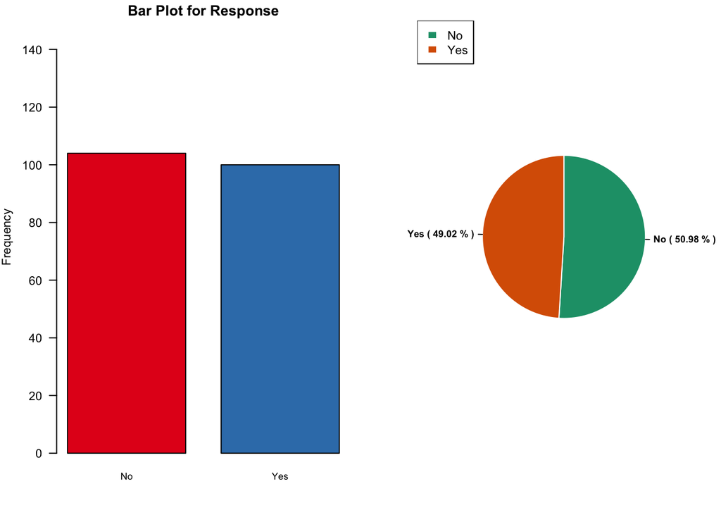

```r
# "Used code mfcol() to organize charts in a matrix of 1 rows and 2 column
par(mfcol=c(1,2))

# Used code mai=c() to control margins inside charts
par(cex=0.7, mai=c(0.6,0.55,0.2,0.1))

#Creating Table
tbar = table(Pets_List$Response)

#Bar Plot
plotResponse = barplot(tbar, main="Bar Plot for Response",
                 xlab = ,
                 ylab = "Frequency",
                col = brewer.pal(15, "Set1"),
                border = "black",
                ylim = c(0,150),
                 las = 1.5,
                cex.lab = 1,
                cex.axis = 1,
                 cex.names = 0.8,
                 space = 0.3)

#Adding Lables
text(x=tbar,
     plotResponse,
     tbar,
     cex=0.8,
     pos = 1)

#Labels Creation for Pie Chart
pieLabel4 = paste( unique(sort(Pets_List$Response)),"(",round(100 * tbar /sum(tbar ), 2),"%",")")


# Plot the pie chart for Fuel Type.
pie1 = pie(tbar , labels = pieLabel4,
           radius = 0.6,
           col =  brewer.pal(7, "Dark2"),
    border = "white",
    lty = 1,
    cex=0.8,
    font = 2,
    clockwise = T)

# Legends Display"
legend("topleft",
       legend = paste(unique(sort(Pets_List$Response))),
       fill = brewer.pal(7, "Dark2"),
       border = "white")
```

**3. CONCLUSIONS**

_ As pet food company, we can market our products to multiple pet owners, given them discounts.

**4. REFERENCES**

1. Wickham, H., & Grolemund, G. (2016). R for data science: import, tidy, transform, visualize, and model data. ” O’Reilly Media, Inc.”
2. Hader, R. (2004). Salary Survey 2004: It’s time to check your role’s return on investment. Nursing Management, 35(7), 28-32.
3. Bluman, A. (2014). Elementary Statistics: A step by step approach 9e. McGraw Hill.

**5. APPENDIX**

An R Markdown file has been attached to this report. The name of the file is Maheswar_Project2.Rmd